# Laboratorio 3.2: Clustering

Andrés Abeliuk, Hernán Sarmiento, Cinthia Sánchez, Jorge Ortiz

Octubre 2022

## ============= Declaración de compromiso ético =============

Nosotros **Benjamín Aguilar y Felipe Keim** , declaramos que realizamos de manera grupal los pasos de la presente actividad. También declaramos no incurrir en copia, ni compartir nuestras respuestas con otras personas ni con otros grupos. Por lo que, ratificamos que las respuestas son de nuestra propia confección y reflejan nuestro propio conocimiento.

# Instrucciones

1. Trabajen en equipos de dos personas. Salvo excepciones, no se corregirá entregas con menos de dos integrantes.
2. Modifiquen este archivo `.ipynb` agregando sus respuestas donde corresponda.
3. Cuando finalicen el laboratorio, **generen un archivo HTML** usando jupyter (ver tutorial 2) y súbanlo a U-Cursos. El laboratorio debe ser entregado sólo por 1 integrante. Si se entrega por más de un integrante, se revisará cualquiera de éstos.

# Estructura del laboratorio

Este laboratorio consiste en 2 partes. La primera son preguntas teóricas en las que no necesita escribir código y corresponden a materia vista en clases. La segunda es una sección para entrenar y evaluar los métodos de clustering, incluyendo la interpretación de los resultados.

# Parte 1: Preguntas teóricas

**1.** ¿En qué se diferencian las tareas de clustering y clasificación? ¿Cuándo usar clustering y cuando clasificación? Liste al menos dos ejemplos de cada tarea.

> Respuesta: Clustering es algoritmo no supervisado, dado que genera grupos a partir de datos sin clases definidas. Por otro lado la clasificación es un método supervisado, el cuál requiere de datos con clases definidas previas para entrenar.

> De esta forma, se utiliza clasificación cuando se cuentan con datos con clases definidas, por ejemplo un modelo de clasificación de imágenes de perros y gatos o un algoritmo de clasificación socioeconómica para asignaciones estatales, y clustering en caso contrario, por ejemplo en segmentación de clientes o creación de grupos de intereses musicales.

**2.** De acuerdo a lo visto en clases, explique cómo bisecting k-mean soluciona el problema de la inicialización de centroides de k-means.

> Respuesta: Cuando se tiene una gran cantidad de clusters, la probabilidad de encontrar una inicialización correcta (un centroide inicial en cada grupo) es muy pequeña, y puede que sin una buena inicialización no sea posible alcanzar los cluster óptimos.

> Utilizar bisecting k-mean soluciona este problema dado que en cada iteración se utilizan dos clusters, por lo que la probabilidad de encontrar una buena inicialización es más alta y es más fácil converger al óptimo.

**3.** Evaluar clusters no es una tarea fácil. ¿Qué formas de evaluar clusters conoce? Nombre al menos 3 formas y describa cómo podría determinar si los clusters son buenos o malos usando cada una de las formas nombradas.

> Respuesta:
- Coeficiente de Silhouette: Si el valor de este coeficiente es cercano a 1, significa que los clusters están bien asignados, en cambio un valor próximo a -1 implica una mala asignación.
- Entropía y pureza: método externo (supervisado) donde se busca minimizar la entropía y maximizar la pureza. Una asignación de clusters se considera buena si tiene una pureza cercana a 1 y una entropía próxima a cero.
- Cohesión y separación: método interno que mide por un lado la distancia intra-cluster (que se busca aproximar a cero) y la distancia inter-cluster (que se busca maximizar). De esta forma, un clustering se considera adecuado si tiene una baja cohesión y una alta separación.

# Parte 2: Preguntas prácticas

Para todo el laboratorio usaremos los siguientes datos. Estos contienen información de clientes de un centro comercial, como la edad, sexo, ingresos anuales y puntaje de gastos. Más información en: https://www.kaggle.com/datasets/kandij/mall-customers

- Para entrenar los modelos deben usar los datos en `X`.
- Para visualizar los datos deben usar una versión con dimensionalidad reducida, los cuales guardaremos en la variable `X_pca`.

```python
import pandas as pd

dataframe = pd.read_csv("https://raw.githubusercontent.com/cinthiasanchez/Data-Mining/main/Mall_Customers.csv")
dataframe.drop('CustomerID', axis=1, inplace=True)
Genre = pd.get_dummies(dataframe['Genre'], prefix='Genre', drop_first=True)

X = pd.concat([dataframe, Genre], axis=1).drop('Genre', axis=1)
X.head()
```

|  | Age | Annual Income (k$) | Spending Score (1-100) | Genre_Male |
| --- | --- | --- | --- | --- |
| 0 | 19 | 15 | 39 | 1 |
| 1 | 21 | 15 | 81 | 1 |
| 2 | 20 | 16 | 6 | 0 |
| 3 | 23 | 16 | 77 | 0 |
| 4 | 31 | 17 | 40 | 0 |

```python
from sklearn.decomposition import PCA

pca = PCA(n_components=2).fit(X)
X_pca = pca.transform(X) #para visualizar
X_pca.shape
```

```
(200, 2)
```

## K-means

Cuando usamos k-means debemos definir previamente el número de clusters que queremos generar. Para estimar un número óptimo usaremos el método del codo. Ejecute el siguiente bloque de código, el cual ejecuta `k-means` para `k` clusters, con `k` variando de 1 a 15 clusters. Cada ejecución de `k-means` elige los centroides iniciales al azar. Puede variar el parámetro `n_init` que indica cuántas veces se ejecutará k-means sobre los datos y entregará el clustering con el menor SSE. También puede variar `max_iter`, que indica cuántas veces iterará una ejecución de k-means.

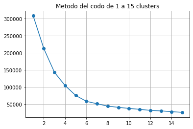

```python
import matplotlib.pyplot as plt
from sklearn.cluster import KMeans

sse = []

clusters = list(range(1, 16))
for k in clusters:
    kmeans = KMeans(n_clusters=k, n_init=10, max_iter=300).fit(X)
    sse.append(kmeans.inertia_)

plt.plot(clusters, sse, marker="o")
plt.title("Metodo del codo de 1 a 15 clusters")
plt.grid(True)
plt.show()
```

**Pregunta 1:** Según el gráfico anterior (usando el método del codo), ¿Cuántos clusters propone usar para este dataset? Escoja dos opciones y justifique su elección. ¿Qué puede decir del efecto de los parámetros `n_init` y `max_iter`? (tuvo que usar valores muy altos, muy bajos, etc.)

> Respuesta: Se propone utilizar tres o cinco clusters. Esto debido a que se puede identificar dos puntos de diminishing returns correspondiente a esta cantidad de clusters (dado que aumentar la cantidad de agrupaciones no disminuye en gran medida el SSE).

> Respuesta: Para los parámetros `n_init` y `max_iter` no es adecuado utilizar valores muy pequeños (como se muestra en el resultado presentado a continuación) pues con estas condiciones el algoritmo no logra encontrar los clusters óptimos. Valores adecuados para este problema en particular son los valores que vienen por defecto (`n_init` = 10 y `max_iter`=300).

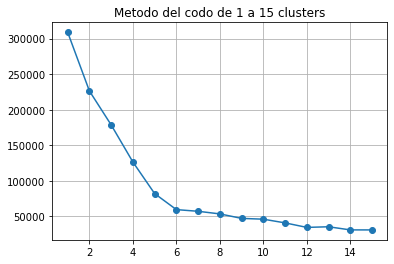

```python
import matplotlib.pyplot as plt
from sklearn.cluster import KMeans

sse = []

clusters = list(range(1, 16))
for k in clusters:
    kmeans = KMeans(n_clusters=k, n_init=1, max_iter=1).fit(X)
    sse.append(kmeans.inertia_)

plt.plot(clusters, sse, marker="o")
plt.title("Metodo del codo de 1 a 15 clusters")
plt.grid(True)
plt.show()
```

**Pregunta 2:** Genere un gráfico para cada uno de los dos `k` elegidos para tener una representación visual de los clusters, y comente lo siguiente:

- ¿Qué puede decir de los clusters generados?
- ¿Existen patrones de agrupación?

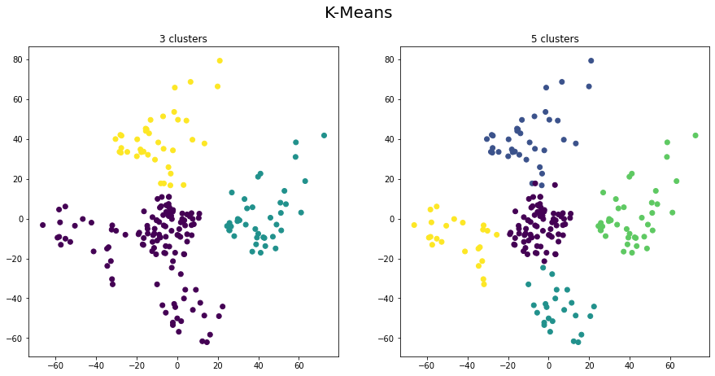

```python
# Respuesta código

kmeans1 = KMeans(n_clusters=3, n_init=10, max_iter=300)
kmeans1.fit(X)

kmeans2 = KMeans(n_clusters=5, n_init=10, max_iter=300)
kmeans2.fit(X)


fig, (ax1, ax2) = plt.subplots(1, 2, figsize=(15,7))
ax1.scatter(X_pca[:, 0], X_pca[:, 1], c=kmeans1.labels_)
ax1.set_title('3 clusters')
ax2.scatter(X_pca[:, 0], X_pca[:, 1], c=kmeans2.labels_)
ax2.set_title('5 clusters')
plt.suptitle("K-Means", fontsize=20)
plt.show()
```

> Respuesta: Se puede observar que efectivamente se forman patrones de agrupación claramente identificables, basándonos en esto mismo, se observa que la cantidad de clusters más adecuada con respecto a las propuestas anteriormente es de cinco.

## DBSCAN

Con DBSCAN necesitamos dos parámetros, `eps`y `min_samples`. El siguiente código permite estimar el valor `eps` usando el método de la rodilla (basado en KNN). La idea de este procedimiento es calcular la distancia promedio de cada punto a sus k vecinos más cercanos los cuales son graficados en orden ascendente. El objetivo es determinar la `rodilla`, que corresponde al valor óptimo de `eps`.

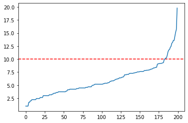

```python
from sklearn.neighbors import NearestNeighbors
import numpy as np

N = 5 #corresponde a 'min_samples'

nbrs = NearestNeighbors(n_neighbors=N).fit(X)
distances, indices = nbrs.kneighbors(X)

distances = np.sort(distances, axis=0)
distances = distances[:,1]
plt.axhline(y=10, color='r', linestyle='--') #Ajuste el valor para y
plt.plot(distances);
```

**Pregunta 3:** Utilizando el método de la rodilla, pruebe varios valores de `y`, y escoja el que usted considere el mejor `y`. Grafique los clusters usando el método DBSCAN haciendo uso del parámetro `eps` (`y`) encontrado previamente, y `min_samples=5`. Comente:

- ¿Por qué escogió el valor `y` como mejor opción?
- ¿Cuántos clusters obtuvo? Imprima los clusters obtenidos.
- ¿Qué puede decir de los clusters generados?

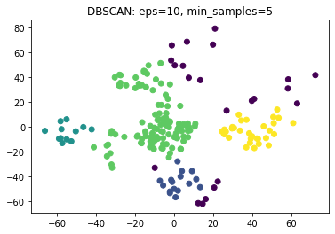

```python
# Respuesta código

from sklearn.cluster import DBSCAN

eps = 10
min_samples = 5

dbscan1 = DBSCAN(eps=eps, min_samples=min_samples).fit(X_pca)
plt.scatter(X_pca[:,0], X_pca[:,1], c=dbscan1.labels_)
plt.title(f"DBSCAN: eps={eps}, min_samples={min_samples}")
plt.show()
```

```python
np.unique(dbscan1.labels_)
```

```
array([-1,  0,  1,  2,  3], dtype=int64)
```

> Respuesta: Se escogió `y=10` dado que es el punto donde ocurre un cambio abrupto en la pendiente de la curva (basándose en el método de la rodilla). Se obtuvieron 4 clusters además de los datos asociados a ruido.

> Se puede observar que se obtuvo una menor cantidad de cluster respecto a los seleccionados usando el método Kmeans, esto debido a que DBSCAN considera algunos datos como outliers, lo que eliminó un cluster que presentaba una gran desviación entre los puntos de este.

**Pregunta 4:** ¿Cómo cambia el resultado si ahora cambia el `N` (el valor de `min_samples`)?

Juegue con distintos valores de `N`, determine el `eps` correspondiente, y describa sus observaciones.

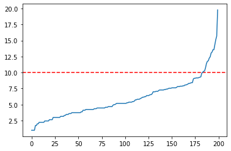

```python
N = 7 #corresponde a 'min_samples'

nbrs = NearestNeighbors(n_neighbors=N).fit(X)
distances, indices = nbrs.kneighbors(X)

distances = np.sort(distances, axis=0)
distances = distances[:,1]
plt.axhline(y=10, color='r', linestyle='--') #Ajuste el valor para y
plt.plot(distances);
```

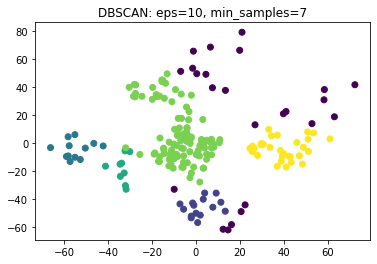

```python
#Respuesta código

from sklearn.cluster import DBSCAN

eps = 10
N = 7

dbscan = DBSCAN(eps=eps, min_samples=N).fit(X_pca)
plt.scatter(X_pca[:,0], X_pca[:,1], c=dbscan.labels_)
plt.title(f"DBSCAN: eps={eps}, min_samples={N}")
plt.show()
```

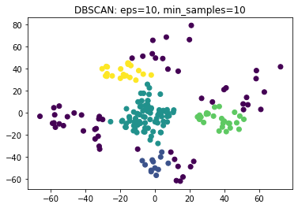

```python
#Respuesta código

from sklearn.cluster import DBSCAN

eps = 10
N = 10

dbscan = DBSCAN(eps=eps, min_samples=N).fit(X_pca)
plt.scatter(X_pca[:,0], X_pca[:,1], c=dbscan.labels_)
plt.title(f"DBSCAN: eps={eps}, min_samples={N}")
plt.show()
```

> Respuesta: Al ir modificando el valor de `N` varía el número mínimo de puntos vecinos que requiere un dato para ser considerado un centroide. Esto implica que al cambiar este valor se verán modificado el número de clusters y los datos pertenecientes a estos. Para el dataset estudiado se obtuvo lo siguiente al modificar N:
- `N=7`:

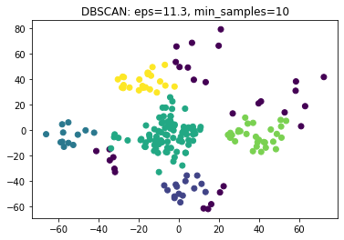

```python
#Respuesta código

from sklearn.cluster import DBSCAN

eps = 11.3
N = 10

dbscan2 = DBSCAN(eps=eps, min_samples=N).fit(X_pca)
plt.scatter(X_pca[:,0], X_pca[:,1], c=dbscan2.labels_)
plt.title(f"DBSCAN: eps={eps}, min_samples={N}")
plt.show()
```

## Clustering Jerárquico Aglomerativo

**Pregunta 5:** Grafique un dendograma con el método `ward` y la métrica `euclidean`. Comente: ¿"visualmente" cuántos clusters propone usar? ¿A qué altura recomendaría cortar el árbol?

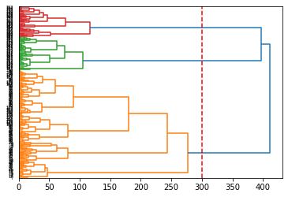

```python
#Respuesta código

from scipy.cluster.hierarchy import dendrogram, linkage

plt.axvline(x=300, color='r', linestyle='--')
Z = linkage(X, 'ward', metric='euclidean')
dn = dendrogram(Z, orientation='right')
```

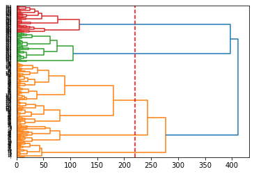

```python
from scipy.cluster.hierarchy import dendrogram, linkage

plt.axvline(x=220, color='r', linestyle='--')
Z = linkage(X, 'ward', metric='euclidean')
dn = dendrogram(Z, orientation='right')
```

> Respuesta: Visualmente se observa que se puede cortar el árbol a un altura de `x=300` para obtener tres clusters. Otra opción puede ser cortar el árbol en `x=220`, obteniendo 5 clusters.

**Pregunta 6:** Implemente el código para asignar clusters a los datos siguiendo lo que usted propuso en la pregunta anterior y visualice los datos con su respectiva asignación. Comente lo siguiente:

- ¿Cuántos clusters obtuvo cortando a la altura que propuso en la pregunta anterior?
- ¿Qué puede decir de los clusters generados?

```python
#Respuesta código

from sklearn.cluster import AgglomerativeClustering

complete_all1 = AgglomerativeClustering(linkage="ward",
                                       affinity='euclidean',
                                       n_clusters=None,
                                       distance_threshold=220).fit(X)

complete_all2 = AgglomerativeClustering(linkage="ward",
                                       affinity='euclidean',
                                       n_clusters=None,
                                       distance_threshold=300).fit(X)

print('Altura 220: ', complete_all1.n_clusters_, 'clusters')
print('Altura 300: ', complete_all2.n_clusters_, 'clusters')
```

```
Altura 220:  5 clusters
Altura 300:  3 clusters
```

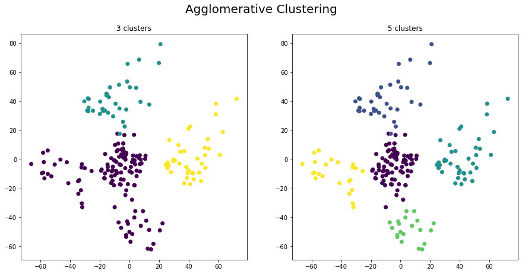

```python
fig, (ax1, ax2) = plt.subplots(1, 2, figsize=(15,7))
ax1.scatter(X_pca[:, 0], X_pca[:, 1], c=complete_all2.labels_)
ax1.set_title('3 clusters')
ax2.scatter(X_pca[:, 0], X_pca[:, 1], c=complete_all1.labels_)
ax2.set_title('5 clusters')
plt.suptitle("Agglomerative Clustering", fontsize=20)
plt.show()
```

> Respuesta textual: Como se mencionó, al cortar en `x=300` y en `x=220` se obtuvieron 3 y 5 clusters respectivamente. Podemos observar que se obtuvieron los mismos clusters que los obtenidos con el método Kmeans, y que no se reconocen datos como outliers. Por otro lado, los patrones de agrupación son claramente identificables en ambos casos.

## Evaluación

Para evaluar clusters existen una serie de métodos y métricas. Para este laboratorio usaremos el **Coeficiente de Silhouette**.

**Pregunta 7:** Para cada uno de los experimentos, los dos de la parte de `kmeans` en la pregunta **2**, los dos de la parte de `dbscan` en la pregunta **3** y **4 (únicamente para el mejor caso)**, y el de `clustering jerárquico` en la pregunta **6**, imprima el Silhouette score de los modelos. Adjunte código.

```python
#Respuesta código

from sklearn.metrics import silhouette_score

print("Dataset X K-Means 1\t", silhouette_score(X, kmeans1.labels_))
print("Dataset X K-Means 2\t", silhouette_score(X, kmeans2.labels_))

# para DBSCAN tenermos que filtrar las labels negativas, ya que representan ruido, no otro cluster:
_filter_label = dbscan.labels_ >= 0
print("Dataset X DBSCAN 1\t", silhouette_score(X[_filter_label], dbscan1.labels_[_filter_label]))
print("Dataset X DBSCAN 2\t", silhouette_score(X[_filter_label], dbscan2.labels_[_filter_label]))

print("Dataset X Clustering jerárquico\t", silhouette_score(X, complete_all1.labels_))
```

```
Dataset X K-Means 1	 0.383798873822341
Dataset X K-Means 2	 0.4440669204743008
Dataset X DBSCAN 1	 0.4039254786953968
Dataset X DBSCAN 2	 0.45601053685283693
Dataset X Clustering jerárquico	 0.43997527212476695
```

**Pregunta 8:** En base a los valores del coeficiente de Silhouette obtenidos para cada método y configuración, ¿cuál considera que es el que tiene mejor resultado? Argumente su respuesta.

**Pregunta 9:** ¿Qué considera que representa cada cluster en este conjunto de datos?

> Respuesta textual: Cada cluster representa un grupo de compradores similares basados en sus características socioeconómicas. Estos son útiles para segmentar los clientes y lograr generar políticas de compras más personalizadas a cada persona. De esta forma, cada cluster representar una "clase de comprador" distinta.